# Path2D

### Laser swiping effect

We’ll see how to fire a laser from off-screen onto a moving target for our last demonstrating.

[figure not shown]

The setup for this scene is as follows:

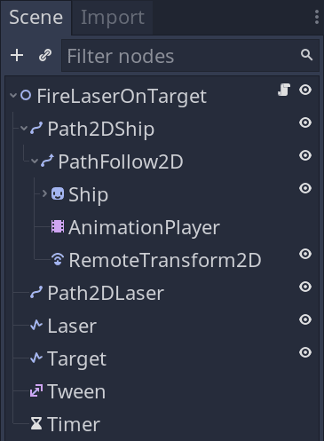

The *Ship* moves in an infinite loop, based on the *Path2DShip* curve.

The laser firing mechanism works like this:

1. Pick a random position on *Path2DLaser*.
2. Rotate the `Line2D` *Target* node randomly for variation.
3. Swipe the `Line2D` *Laser* over the segment defined by *Target* using the `Tween` node.

We fire the laser every time `Timer` emits the `timeout` signal.

We’re using the `RemoteTransform2D` node under `PathFollow2D` to make *Target* follow the *Ship* node.

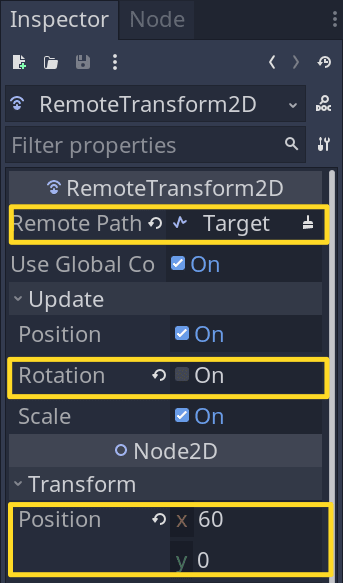

I gave it a *Position* offset so that the laser swiping starts at the tip of the *Ship* because it’s a moving object.

For *Laser*, I used a *Width* of `4`, its *Color* is `#eb564b`, and I turned *Antialiased* on for a smoother look.

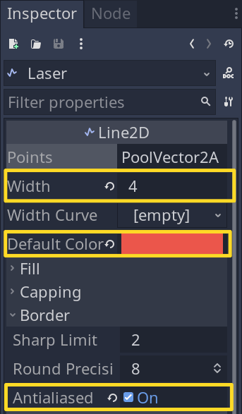

For *Target*, I used a *Width* of `1`, the same `Color`, `#eb564b` and manually defined *Points* for a symmetrical horizontal segment.

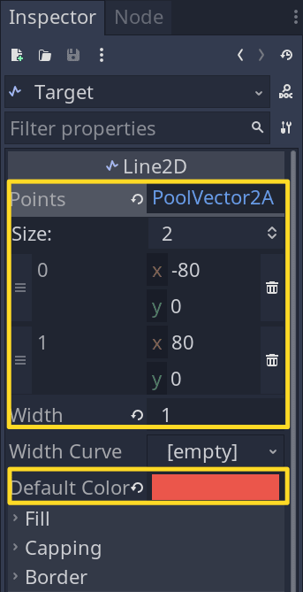

We also make sure to turn off *Rotation* because we want to align *Target* randomly for each shot.

To start coding, we store the desired laser swipe duration in a constant and a `RandomNumberGenerator` to randomize the laser.

We also store references to all the nodes we need in the script.

```
## The duration of the laser beam's swipe animation in seconds.
const LASER_ANIMATION_DURATION := 0.4

# We use a random number generator to randomize the angle of the swipe
# animation, as well as the position of the laser outside the screen.
var _rng := RandomNumberGenerator.new()

onready var _path_follow: PathFollow2D = $Path2DShip/PathFollow2D
onready var _path_laser_curve: Curve2D = $Path2DLaser.curve
onready var _laser: Line2D = $Laser
onready var _target: Line2D = $Target
onready var _tween: Tween = $Tween
onready var _timer: Timer = $Timer
```

As I said, we fire the laser every time the `Timer` emits the `timeout` signal.

```
func _ready() -> void:
    _rng.randomize()
    _timer.connect("timeout", self, "_on_Timer_timeout")
    _tween.connect("tween_all_completed", _laser, "set_visible", [false])
    _laser.points = PoolVector2Array([Vector2.ZERO, Vector2.ZERO])
    _laser.visible = false
```

We finish off with the `_on_Timer_timout()` and the `_animate_laser_swipe()` functions:

```
func _on_Timer_timeout() -> void:
    # Rotate `Target` randomly for some variation.
    _target.rotation = _rng.randf_range(0, PI / 2)

    # Get a random location off-sreen, on `Path2DLaser`. This is the origin point for
    # the incoming laser.
    _laser.points[0] = _path_laser_curve.interpolate_baked(
        _rng.randf_range(0, _path_laser_curve.get_baked_length())
    )

    # Since the target is controlled by a `RemoteTransform2D` and a `PathFollow2D`, we need to
    # convert its points in global coordinates.
    var target: PoolVector2Array = _target.transform.xform(_target.points)

    _tween.stop_all()
    _tween.interpolate_method(
        self, "_animate_laser_swipe", target[0], target[1], LASER_ANIMATION_DURATION,
        Tween.TRANS_LINEAR, Tween.EASE_IN
    )
    _tween.start()
    # Seeking forces the tween to update the animation state. Otherwise, the laser's position won't
    # update until the next frame, causing visual artifacts.
    _tween.seek(0.0)
    _laser.visible = true

    # We wait for a random amount of time between one and two seconds before
    # firing again.
    _timer.wait_time = _rng.randf_range(1, 2)
    _plop.restart()


## Gets called on every `Tween` step. Since the origin of the laser is fixed, we swipe by
## changing the second point on the Line2D node.
func _animate_laser_swipe(point: Vector2) -> void:
    _laser.points[1] = point
    _plop.position = point
```

### How do we create regular geometric paths (ellipses, rectangles, etc.)?

There are no built-in methods to create regular 2D shapes in Godot. You’ll have to write a geometric library to use as either a plug-in or in real-time.

One way to do it is to rely on the internal Godot code for some built-in shapes for the `CollisionShape2D` node.

The code is simple enough that it can be converted to GDScript without much hassle.

For example, we can find the [CapsuleShape2D._get_points()](https://github.com/godotengine/godot/blob/4c2559df1d9b68ba406d66d1f82fba54d364c903/scene/resources/capsule_shape_2d.cpp#L37) backend implementation, and either copy it and convert it to a GDScript function or use it as a starting point for making your implementation.

You can use this method to convert any other `Shape2D` resources internal function for your purpose.

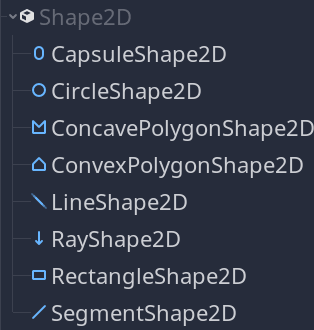